# Iris Dataset - Classification and Visualization Tour De Force

Everyone that has even dabbled in data science has at the very least heard of the Iris dataset. It is extremely well documented as a database used in pattern recognition and is one of the seminal and fundamental pieces of literature in the field.

The dataset looks at the petal and sepal lengths/width in cm, for 3 different types of Iris flowers (setosa, virginica, and versicolour). Each type of Iris has 50 observations associated with it.

Given that, the common question that is posed when dealing with this dataset is:

"Given a sepal length and width as well as a petal length and width for an Iris flower, can you classify it as setosa, virginica, or versicolour?"

Since flower class is not a continuous variable then this is clear a classification question that we are being asked to answer.

In this post, I'll be exploring a variety of classifiers and see which one provides the most accurate classification. I'll also be playing around with visualizations and statistics.

With that said, let's go!

## Modules Used in this Project

```python
import pandas as pd
import numpy as np
import seaborn as sns
import matplotlib.pyplot as plt
from tqdm import *

#For Exploratory Data Analysis (EDA)
from pandas_profiling import ProfileReport

#For feature selection
from sklearn.feature_selection import SelectKBest
from sklearn.feature_selection import chi2

#For data splitting
from sklearn.model_selection import train_test_split
from sklearn import preprocessing

# Get ML  classifiers
from sklearn.linear_model import Perceptron
from sklearn.naive_bayes import GaussianNB
from sklearn.ensemble import RandomForestClassifier
from xgboost import XGBClassifier
from sklearn.neighbors import KNeighborsClassifier
from sklearn.tree import DecisionTreeClassifier
from sklearn.ensemble import GradientBoostingClassifier
from sklearn.gaussian_process import GaussianProcessClassifier
from sklearn.svm import SVC
from sklearn.neural_network import MLPClassifier

#Get model metrics for model evaluation
from sklearn.metrics import confusion_matrix, mean_squared_error, r2_score, accuracy_score
from sklearn.metrics import classification_report, roc_curve, auc
from sklearn.model_selection import cross_val_predict
from sklearn.decomposition import PCA
from sklearn.metrics.pairwise import cosine_similarity

#For confusion matrix display
import scikitplot as skplt

#For parameter grid search optimization
from sklearn.model_selection import GridSearchCV
from sklearn.metrics import accuracy_score, recall_score, precision_score, f1_score

#For simplified understanding of the importance model features
import eli5
from eli5.sklearn import PermutationImportance

#For generating partial dependence plots
from pdpbox import pdp, info_plots

#For calculation of shap values to further assess contributions of model features
import shap

#Yeah yeah this is overkill
import tensorflow as tf
from tensorflow.keras import layers
```

```python
df = pd.read_csv("iris.data",
                 header = None,
                 names = ['sepal_length','sepal_width','petal_length','petal_width','class'])
df
```

|  | sepal_length | sepal_width | petal_length | petal_width | class |
| --- | --- | --- | --- | --- | --- |
| 0 | 5.1 | 3.5 | 1.4 | 0.2 | Iris-setosa |
| 1 | 4.9 | 3.0 | 1.4 | 0.2 | Iris-setosa |
| 2 | 4.7 | 3.2 | 1.3 | 0.2 | Iris-setosa |
| 3 | 4.6 | 3.1 | 1.5 | 0.2 | Iris-setosa |
| 4 | 5.0 | 3.6 | 1.4 | 0.2 | Iris-setosa |
| ... | ... | ... | ... | ... | ... |
| 145 | 6.7 | 3.0 | 5.2 | 2.3 | Iris-virginica |
| 146 | 6.3 | 2.5 | 5.0 | 1.9 | Iris-virginica |
| 147 | 6.5 | 3.0 | 5.2 | 2.0 | Iris-virginica |
| 148 | 6.2 | 3.4 | 5.4 | 2.3 | Iris-virginica |
| 149 | 5.9 | 3.0 | 5.1 | 1.8 | Iris-virginica |

150 rows × 5 columns

```python
df.reset_index(drop=True, inplace=True) #Drop index prior to generating report
report = ProfileReport(df)
report
```

[interactive chart not shown]

Lovely. No missing values and the data is uniformly distributed. If only all data was like this lol

We can also see from the generated histograms that the sepal length and width are normally distributed. However, the petal length and width are clearly divided into two separate distributions (is this an opportunity to apply clustering techniques?)

Let me generate a pair plot to get a birds-eye view of these interactions.

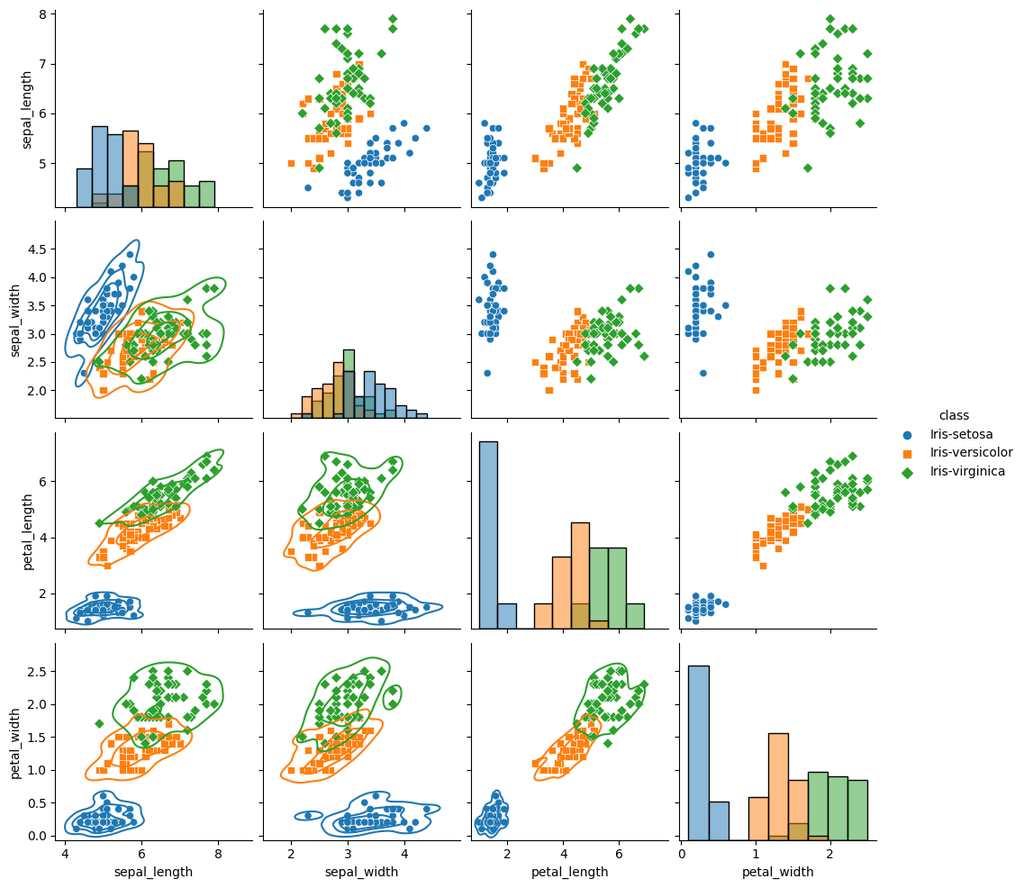

```python
g = sns.pairplot(df, hue='class', diag_kind="hist", markers=["o", "s", "D"])
g.map_lower(sns.kdeplot, levels=4, color=".2")
```

Hmm, very nice! Here's a few things that we can readily see from this plot.

Sepal length and sepal width are highly intermixed for the classes versicolor and virginica. As such, this would make classifying the iris classes through this difficult.

Sepal length and petal length exhibit good separation between them (look at the KDE contours) and thus, could lead to accurate classification.

Petal width and petal length also exhibit good separation between them and could also lead to accurate classification between them.

Let's take a look at the violin plots to get a better idea of the probability densities of the features.

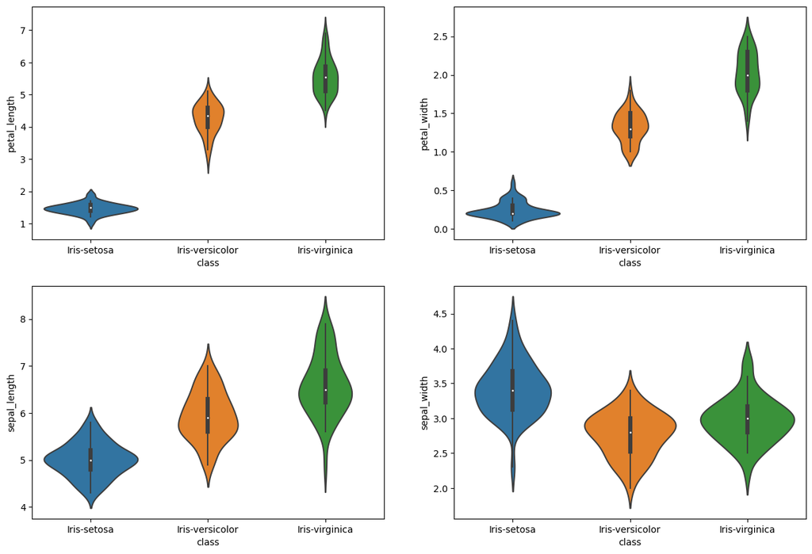

```python
plt.figure(figsize=(15,10))
plt.subplot(2,2,1)
sns.violinplot(x='class', y='petal_length',data=df)
plt.subplot(2,2,2)
sns.violinplot(x='class', y='petal_width',data=df)
plt.subplot(2,2,3)
sns.violinplot(x='class', y='sepal_length',data=df)
plt.subplot(2,2,4)
sns.violinplot(x='class', y='sepal_width',data=df)
```

From here we can see the following:

- Sepal length for virginica spans approximately 4-9 centimeters. This is not good for maximizing separability.
- Sepal width for all 3 classes overlap a fair bit and would thus make ensuring separability difficult.
- Petal length and petal widths for all 3 classes are well separated from one another. This provides more support for choosing them as the basis of our classification models.

```python
df.columns
```

```
Index(['sepal_length', 'sepal_width', 'petal_length', 'petal_width', 'class'], dtype='object')
```

## Playing With Visualizations

Now I'm just going to play around with visualizations for a bit.

### 2D Density Plots

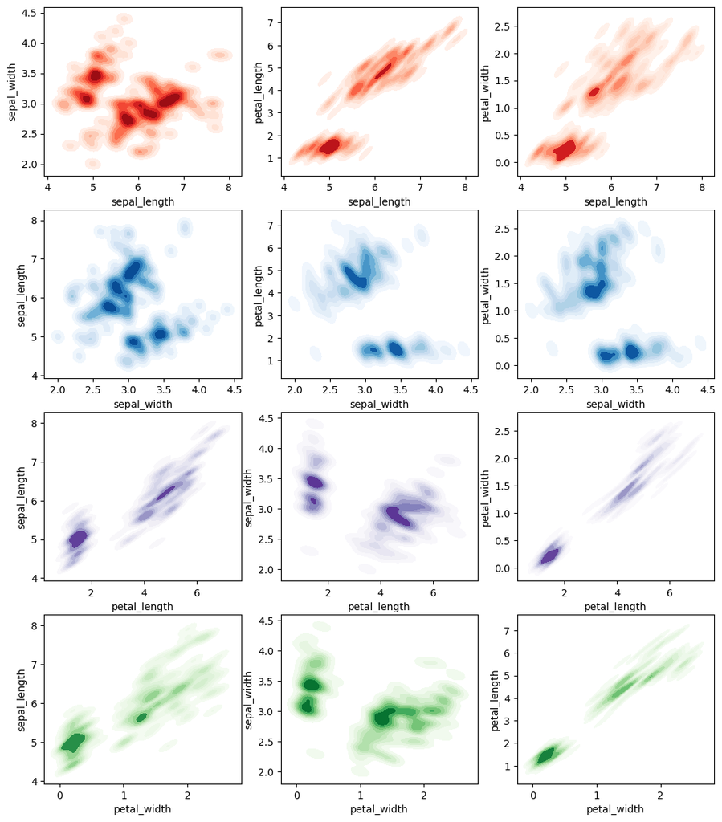

```python
names = ['sepal_length','sepal_width','petal_length','petal_width']
f, ax = plt.subplots(4,3,figsize=(12, 14))
ax = ax.ravel()
for i in range(3):
    features = df.columns[1:4]
    sns.kdeplot(df[names[0]], df[features[i]], cmap="Reds", shade=True, bw=.15, ax = ax[i])

    features = list(df.columns[0:1]) +  list(df.columns[2:4])
    sns.kdeplot(df[names[1]], df[features[i]], cmap="Blues", shade=True, bw=.15, ax = ax[i+3])

    features = list(df.columns[0:2]) +  list(df.columns[3:4])
    sns.kdeplot(df[names[2]], df[features[i]], cmap="Purples", shade=True, bw=.15, ax = ax[i+6])

    features = df.columns[0:4]
    sns.kdeplot(df[names[3]], df[features[i]], cmap="Greens", shade=True, bw=.15, ax = ax[i+9])
plt.show()
```

### Bar Plots

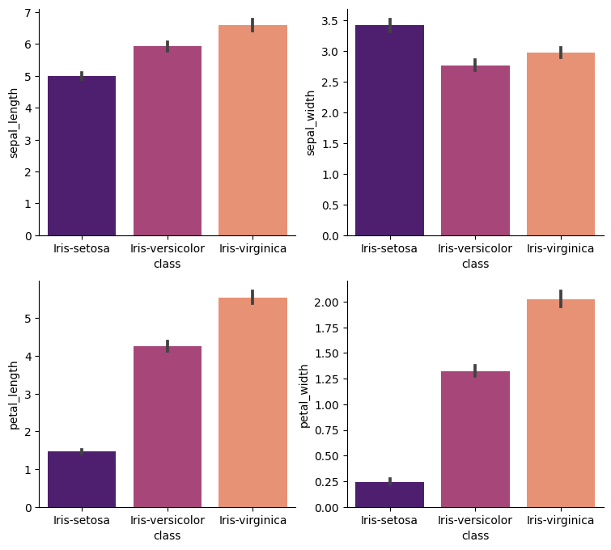

```python
f, ax = plt.subplots(2,2,figsize=(9, 8))
ax = ax.ravel()
features = df.columns[:4]
i = 0
for feature in features:
    sns.despine(f)
    sns.barplot(x='class', y=feature, data=df, palette='magma', ax = ax[i])
    i += 1
plt.show()
```

### Horizontal Bar Plots

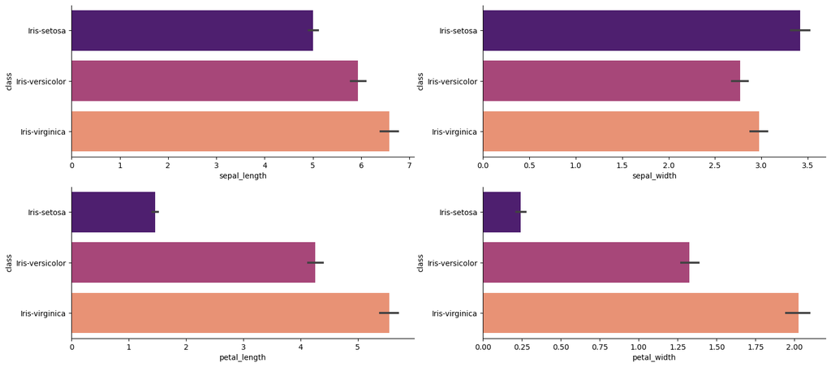

```python
f, ax = plt.subplots(2,2,figsize=(18, 8))
ax = ax.ravel()
features = df.columns[:4]
i = 0
for feature in features:
    sns.despine(f)
    sns.barplot(x=feature, y='class', data=df, palette='magma', ax = ax[i], orient='h')
    i += 1
plt.show()
```

### Heatmaps

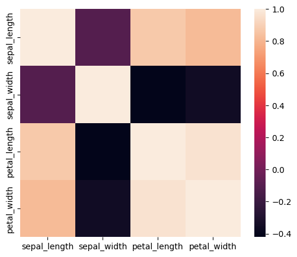

```python
f= plt.figure(figsize=(6, 5))
sns.heatmap(df.drop(['class'], axis=1).corr())
plt.show()
```

## Network Chart

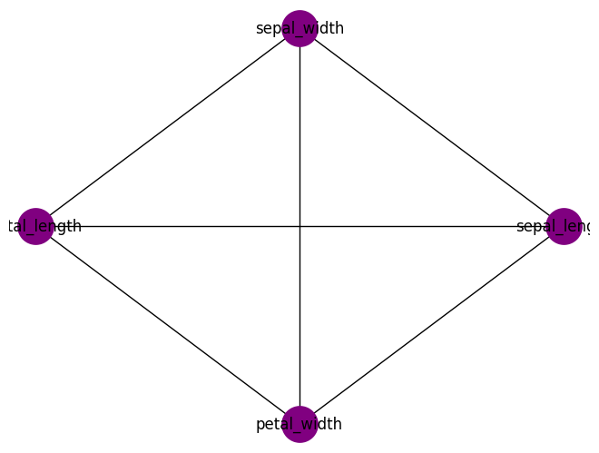

```python
# import networkx library
import networkx as nx

# Calculate the correlation between individuals.
corr = df.iloc[:,0:4].corr()

# Transform it in a links data frame (3 columns only):
links = corr.stack().reset_index()
links.columns = ['var1', 'var2','value']

# correlation
threshold = -1

# Keep only correlation over a threshold and remove self correlation (cor(A,A)=1)
links_filtered=links.loc[ (links['value'] >= threshold ) & (links['var1'] != links['var2']) ]

# Build your graph
G=nx.from_pandas_edgelist(links_filtered, 'var1', 'var2')

# Plot the network
nx.draw_circular(G, with_labels=True,
                 node_color='purple',
                 node_size=300,
                 edge_color='black',
                 linewidths=12,
                 font_size=12)
```

## Venn Diagrams

A Venn diagram is used to show the logical relation between sets.

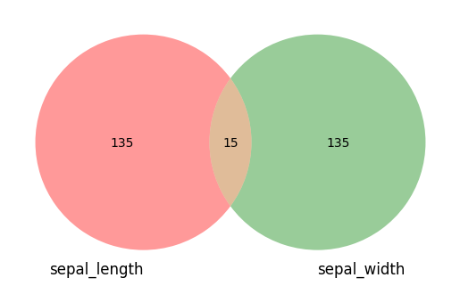

```python
# venn2
from matplotlib_venn import venn2
sepal_length = df.iloc[:,0]
sepal_width  = df.iloc[:,1]
petal_length = df.iloc[:,2]
petal_width  = df.iloc[:,3]
# First way to call the 2 group Venn diagram
venn2(subsets = (len(sepal_length)-15, len(sepal_width)-15, 15),
      set_labels = ('sepal_length', 'sepal_width'))
plt.show()
```

```python
df
```

|  | sepal_length | sepal_width | petal_length | petal_width | class |
| --- | --- | --- | --- | --- | --- |
| 0 | 5.1 | 3.5 | 1.4 | 0.2 | Iris-setosa |
| 1 | 4.9 | 3.0 | 1.4 | 0.2 | Iris-setosa |
| 2 | 4.7 | 3.2 | 1.3 | 0.2 | Iris-setosa |
| 3 | 4.6 | 3.1 | 1.5 | 0.2 | Iris-setosa |
| 4 | 5.0 | 3.6 | 1.4 | 0.2 | Iris-setosa |
| ... | ... | ... | ... | ... | ... |
| 145 | 6.7 | 3.0 | 5.2 | 2.3 | Iris-virginica |
| 146 | 6.3 | 2.5 | 5.0 | 1.9 | Iris-virginica |
| 147 | 6.5 | 3.0 | 5.2 | 2.0 | Iris-virginica |
| 148 | 6.2 | 3.4 | 5.4 | 2.3 | Iris-virginica |
| 149 | 5.9 | 3.0 | 5.1 | 1.8 | Iris-virginica |

150 rows × 5 columns

## Cluster Map

Plot a matrix dataset as a hierarchically-clustered heatmap.

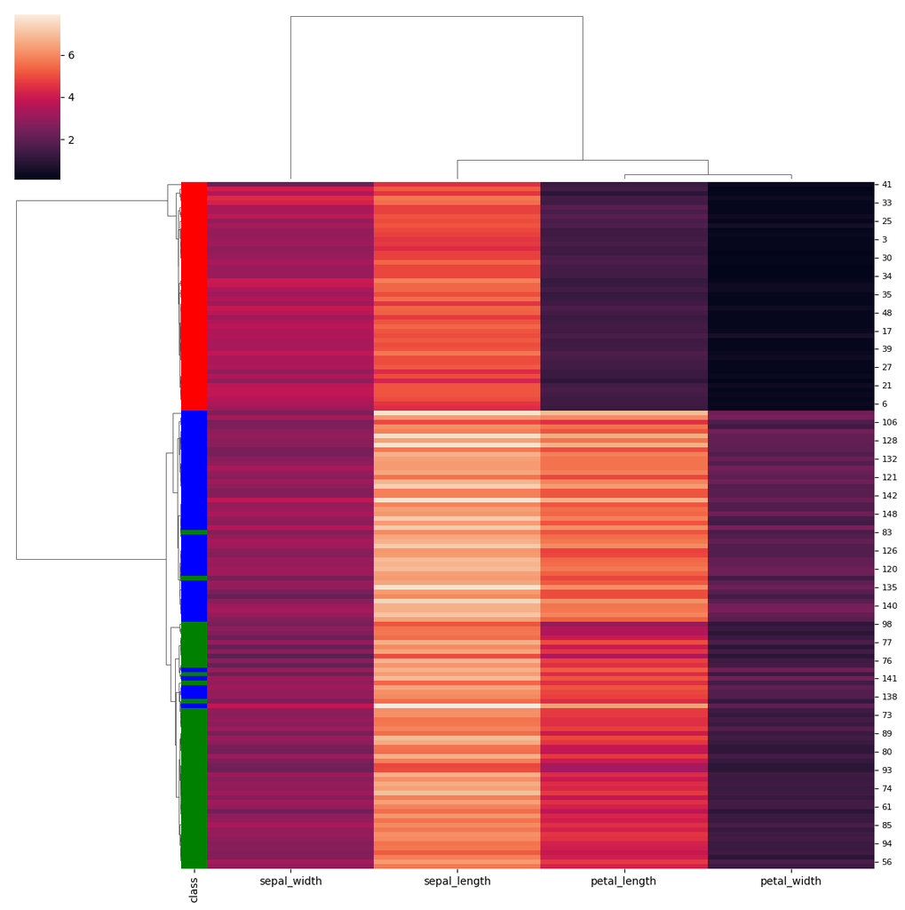

```python
features = df.columns[:4]
# cluster map (dendogram and tree)
df2  = df.loc[:,features]
df1  = df['class']
x = dict(zip(df1.unique(),"rgb"))
row_colors = df1.map(x)
cg = sns.clustermap(df2,row_colors=row_colors,figsize=(12, 12),metric="correlation")
plt.setp(cg.ax_heatmap.yaxis.get_majorticklabels(),rotation = 0,size =8)
plt.show()
```

```python
def model_assess(X_train, X_test, y_train, y_test, model, title = "Default"):

    model.fit(X_train, y_train)

    preds_test  = model.predict(X_test)
    preds_train = model.predict(X_train)

    cm = confusion_matrix(y_test, preds_test)

    sensitivity = cm[0,0]/(cm[0,0]+cm[1,0])
    specificity = cm[1,1]/(cm[1,1]+cm[0,1])

    #print('Accuracy', title, ':', round(accuracy_score(y_test, preds), 5), '\n')
    score = round(accuracy_score(y_test, preds_test), 5);

    rf_results = pd.DataFrame([title,score,sensitivity,specificity]).transpose()
    rf_results.columns = ['Method','Training Score', 'Sensitivity', 'Specificity']

    return preds_train, preds_test, rf_results

def multi_model_assess(df, models, y_predict):
    all_model_results = [] #This will contain all model results for each dependent variable
    all_X_test  = []
    all_X_train = []
    all_y_test_p  = []
    all_y_train_p = []
    all_y_train = []
    #First loop will define dependent/independent variables and split data into test/training sets
    n_vars = len(y_predict)

    for dependent in y_predict:
        model_results = [] #Array with dataframes for a given dependent variable
        #Designate independent and dependent variables
        x  = df.drop([dependent], axis = 1)
        y  = df[dependent]
        #Split data into test and training sets
        X_train, X_test, y_train, y_test = train_test_split(x, y,
                                                            test_size = 0.2,
                                                            )

        #Populate the array of observed values for the dependent variable
        all_y_train.append(y_train)

        pbar = tqdm(range(len(models)), desc="Variable Processed", position = 0, leave = True)#Add progress bar
        #Process each of the desired models
        for model, model_name in models:
            if model_name == 'XGBoost':
                le = preprocessing.LabelEncoder()
                le.fit(y_train)
                y_train = le.transform(y_train)
                le.fit(y_test)
                y_test = le.transform(y_test)

            y_train_pred,y_test_pred, results = model_assess(X_train, X_test, y_train, y_test, model, title = model_name)

            model_results.append(results)
            all_X_test.append(X_test)
            all_X_train.append(X_train)
            all_y_test_p.append(y_test_pred)
            all_y_train_p.append(y_train_pred)
            pbar.update(1)
        all_model_results.append(model_results)
        #pbar.update(1)
        #pbar.refresh()

    pbar.close()
    return all_model_results, all_X_test, all_X_train, all_y_test_p, all_y_train_p, all_y_train
```

I anticipate all of these models to perform excellently. Therefore, I'll just run them with their default parameters. I'll initiate them below and run them.

```python
lp = Perceptron()
nb = GaussianNB()
rf = RandomForestClassifier()
xg = XGBClassifier()
kn = KNeighborsClassifier()
dt = DecisionTreeClassifier()
gb = GradientBoostingClassifier()
gp = GaussianProcessClassifier()
sv = SVC()
nn = MLPClassifier()

models =  [(lp,'Perceptron'),
           (nb,'GaussianNB'),
           (rf,'Random Forest'),
           (xg,'XGBoost'),
           (kn,'K Neighbors'),
           (dt,'DecisionTree'),
           (gb,'Gradient Boosting'),
           (gp,'GaussianProcess'),
           (sv,'SVC'),
           (nn,'MLP')]

y_predict  = ['class']

all_model_results, _, _, all_y_test_p, all_y_train_p, all_y_train = multi_model_assess(df,
                                                                                       models,
                                                                                       y_predict)
```

Generating all these models took less than a second. Let's see how they performed.

```python
score_df_results = pd.concat(all_model_results[0],
                ignore_index=True).sort_values('Training Score',axis = 0, ascending = False)
score_df_results
```

|  | Method | Training Score | Sensitivity | Specificity |
| --- | --- | --- | --- | --- |
| 4 | K Neighbors | 1.0 | 1.0 | 1.0 |
| 7 | GaussianProcess | 1.0 | 1.0 | 1.0 |
| 8 | SVC | 1.0 | 1.0 | 1.0 |
| 2 | Random Forest | 0.96667 | 1.0 | 1.0 |
| 3 | XGBoost | 0.96667 | 1.0 | 1.0 |
| 5 | DecisionTree | 0.96667 | 1.0 | 1.0 |
| 6 | Gradient Boosting | 0.96667 | 1.0 | 1.0 |
| 9 | MLP | 0.96667 | 1.0 | 1.0 |
| 1 | GaussianNB | 0.93333 | 1.0 | 1.0 |
| 0 | Perceptron | 0.73333 | 1.0 | 0.928571 |

As expected, all models performed excellently. The Perceptron model however did perform much worse than the rest. Since generating these models is quite fast, I think it'd be nice to explore the effect that different parameters have on the classification accuracy. Let's check that out for a few of those models.

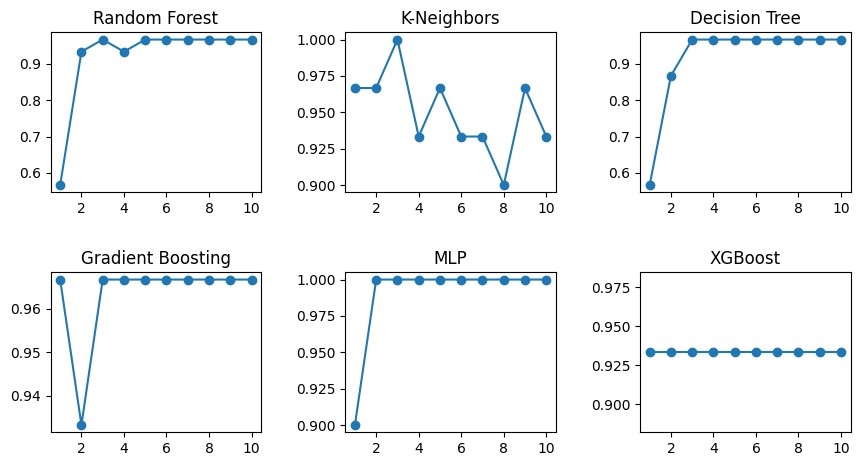

```python
#Split data
x = df.drop(['class'], axis = 1)
y = df['class']
X_train, X_test, y_train, y_test = train_test_split(x, y, test_size = 0.2)

#Define iterator parameters
max_depth_list = [1,2,3,4,5,6,7,8,9,10]
k_list = list(range(1,11))
hidden_layer_sizes_list = [25,50,75,100,125,150,175,200,250,300]

#Create dataframes to hold results
a = pd.Series(); b = pd.Series()
c = pd.Series(); d = pd.Series()
e = pd.Series(); f = pd.Series()

#Plot accuracy for each model as parameter varies
fig, ax = plt.subplots(2,3,figsize = (10, 5))
ax = ax.ravel()

#Random Forest
for j in range(len(max_depth_list)):
    rfc=RandomForestClassifier(max_depth=max_depth_list[j]).fit(X_train,y_train)
    prediction=rfc.predict(X_test)
    a = a.append(pd.Series(accuracy_score(prediction,y_test)))
ax[0].plot(max_depth_list,a, marker = 'o')
ax[0].set_title('Random Forest')

#K-Neighbors
for j in list(range(1,11)):
    knn=KNeighborsClassifier(n_neighbors=j).fit(X_train,y_train)
    prediction=knn.predict(X_test)
    b = b.append(pd.Series(accuracy_score(prediction,y_test)))
ax[1].plot(k_list,b, marker = 'o')
ax[1].set_title('K-Neighbors')

#Decision Tree
for j in range(len(max_depth_list)):
    dtc=DecisionTreeClassifier(max_depth=max_depth_list[j]).fit(X_train,y_train)
    prediction=dtc.predict(X_test)
    c = c.append(pd.Series(accuracy_score(prediction,y_test)))
ax[2].plot(max_depth_list,c, marker = 'o')
ax[2].set_title('Decision Tree')

#Gradient Boosting
for j in range(len(max_depth_list)):
    gbc=GradientBoostingClassifier(max_depth=max_depth_list[j]).fit(X_train,y_train)
    prediction=gbc.predict(X_test)
    d= d.append(pd.Series(accuracy_score(prediction,y_test)))
ax[3].plot(max_depth_list,d, marker = 'o')
ax[3].set_title('Gradient Boosting')

#MLP Classifier
for j in range(len(max_depth_list)):
    mlp=MLPClassifier(hidden_layer_sizes=hidden_layer_sizes_list[j]).fit(X_train,y_train)
    prediction=mlp.predict(X_test)
    e = e.append(pd.Series(accuracy_score(prediction,y_test)))
ax[4].plot(max_depth_list,e, marker = 'o')
ax[4].set_title('MLP')

#XGBoost Classifier
le = preprocessing.LabelEncoder()
le.fit(y_train)
y_train = le.transform(y_train)
le.fit(y_test)
y_test = le.transform(y_test)
for j in range(len(max_depth_list)):
    xgb=XGBClassifier(max_depth=max_depth_list[j]).fit(X_train,y_train)
    prediction=xgb.predict(X_test)
    f = f.append(pd.Series(accuracy_score(prediction,y_test)))
ax[5].plot(max_depth_list,f, marker = 'o')
ax[5].set_title('XGBoost')

plt.subplots_adjust(left=0.1, bottom=0.1, right=0.9,
                    top=0.9, wspace=0.4, hspace=0.5)
plt.show()
```

```python
model_names = ['Random Forest','K-Neighbors',
               'Decision Tree','Gradient Boosting','MLP','XGBoost']
acc_scores_df = pd.concat([a,b,c,d,e,f],axis=1,join='outer',ignore_index=True)
acc_scores_df.columns = model_names
acc_scores_df.reset_index()
acc_scores_df
```

|  | Random Forest | K-Neighbors | Decision Tree | Gradient Boosting | MLP | XGBoost |
| --- | --- | --- | --- | --- | --- | --- |
| 0 | 0.566667 | 0.966667 | 0.566667 | 0.966667 | 0.9 | 0.933333 |
| 0 | 0.933333 | 0.966667 | 0.866667 | 0.933333 | 1.0 | 0.933333 |
| 0 | 0.966667 | 1.000000 | 0.966667 | 0.966667 | 1.0 | 0.933333 |
| 0 | 0.933333 | 0.933333 | 0.966667 | 0.966667 | 1.0 | 0.933333 |
| 0 | 0.966667 | 0.966667 | 0.966667 | 0.966667 | 1.0 | 0.933333 |
| 0 | 0.966667 | 0.933333 | 0.966667 | 0.966667 | 1.0 | 0.933333 |
| 0 | 0.966667 | 0.933333 | 0.966667 | 0.966667 | 1.0 | 0.933333 |
| 0 | 0.966667 | 0.900000 | 0.966667 | 0.966667 | 1.0 | 0.933333 |
| 0 | 0.966667 | 0.966667 | 0.966667 | 0.966667 | 1.0 | 0.933333 |
| 0 | 0.966667 | 0.933333 | 0.966667 | 0.966667 | 1.0 | 0.933333 |

## Iris Classification with Tensorflow (Because why not?)

Yeah, this is overkill, but it's kinda funny so I'm going to do it lol I'm going to build a neural network to classify the Iris dataset. I'll also make sure I'm using my GPU because might as well go all out at this point right?

```python
print("Num GPUs Available: ", len(tf.config.list_physical_devices('GPU')))
```

```
Num GPUs Available:  1
```

Cool. GPU is ready to rock. Let's create the X and Y sets. X are going to be the each of the 4 numerical attributes we have for each flower. Y will be the Iris classes.

```python
#Split the data into X and y
X = df.iloc[:,0:4].values
y = df.iloc[:,4].values
print(X.shape)
print(y.shape)
```

```
(150, 4)
(150,)
```

Since the 'class' is a categorical variable, we need to one hot encode it so that it can be parsed by the keras/tensorflow API.

```python
from sklearn.preprocessing import LabelEncoder
encoder =  LabelEncoder()
y1 = encoder.fit_transform(y)
```

Convert target into one hot encoding

```python
Y = pd.get_dummies(y1).values
```

Now I'll convert X and Y into train and test data using an 80/20 split

```python
X_train, X_test, y_train, y_test = train_test_split(X, Y, test_size=0.2, random_state=0)
```

Build the model

```python
model = tf.keras.Sequential([
    tf.keras.layers.Dense(10, activation='relu'),
    tf.keras.layers.Dense(10, activation='relu'),
    tf.keras.layers.Dense(3, activation='softmax')
  ])
model
```

```
<keras.engine.sequential.Sequential at 0x24533aee608>
```

Compile the model

```python
model.compile(optimizer='rmsprop',
              loss='categorical_crossentropy',
              metrics=['accuracy'])
```

Train the model

```python
model.fit(X_train, y_train, batch_size=50, epochs=100, verbose = 1)
```

```
<keras.callbacks.History at 0x2453301c288>
```

Let's evaluate the model now

```python
loss, accuracy = model.evaluate(X_test, y_test, verbose=0)
print('Test loss:', loss)
print('Test accuracy:', accuracy)
```

```
Test loss: 0.055190205574035645
Test accuracy: 1.0
```

What do you know... 100% classification accuracy lol

Let's test the model

```python
y_pred = model.predict(X_test)
y_pred
```

```
array([[8.65000627e-10, 5.05787460e-03, 9.94942129e-01],
       [8.45906383e-04, 9.92336690e-01, 6.81743305e-03],
       [9.99951601e-01, 4.83444455e-05, 2.09866506e-08],
       [1.99689794e-08, 1.09439008e-01, 8.90560985e-01],
       [9.99779165e-01, 2.20587171e-04, 2.02363935e-07],
       [3.23737218e-11, 1.42846827e-03, 9.98571515e-01],
       [9.99811709e-01, 1.88195147e-04, 1.71240984e-07],
       [4.88932565e-05, 9.72505212e-01, 2.74459049e-02],
       [5.52104466e-05, 9.79511499e-01, 2.04332117e-02],
       [4.12426452e-04, 9.91817415e-01, 7.77022215e-03],
       [1.51192410e-07, 1.12356484e-01, 8.87643397e-01],
       [6.24706663e-05, 9.64046240e-01, 3.58911864e-02],
       [5.49453143e-05, 9.28876460e-01, 7.10685849e-02],
       [4.72179418e-05, 9.56222236e-01, 4.37305421e-02],
       [2.45379488e-05, 8.44014764e-01, 1.55960679e-01],
       [9.99765813e-01, 2.33910847e-04, 2.55687127e-07],
       [2.85931492e-05, 8.39486361e-01, 1.60484999e-01],
       [5.22995470e-05, 8.07655513e-01, 1.92292258e-01],
       [9.99572337e-01, 4.27098508e-04, 5.55696090e-07],
       [9.99901652e-01, 9.82823622e-05, 5.42521654e-08],
       [1.69271956e-08, 2.15052944e-02, 9.78494763e-01],
       [1.06775515e-05, 5.49171984e-01, 4.50817287e-01],
       [9.99315739e-01, 6.83565391e-04, 7.55828637e-07],
       [9.99302506e-01, 6.96144474e-04, 1.35215407e-06],
       [2.41083308e-06, 4.41281110e-01, 5.58716476e-01],
       [9.99845386e-01, 1.54338166e-04, 1.97369999e-07],
       [9.99433696e-01, 5.65807684e-04, 4.27161638e-07],
       [1.81781012e-04, 9.84097779e-01, 1.57203190e-02],
       [2.12756800e-03, 9.86303151e-01, 1.15693072e-02],
       [9.99529839e-01, 4.69720573e-04, 4.48577765e-07]], dtype=float32)
```

```python
actual = np.argmax(y_test,axis=1)
predicted = np.argmax(y_pred,axis=1)
print(f"Actual: {actual}")
print(f"Predicted: {predicted}")
```

```
Actual: [2 1 0 2 0 2 0 1 1 1 2 1 1 1 1 0 1 1 0 0 2 1 0 0 2 0 0 1 1 0]
Predicted: [2 1 0 2 0 2 0 1 1 1 2 1 1 1 1 0 1 1 0 0 2 1 0 0 2 0 0 1 1 0]
```